# HOMEWORK 1

```python
import pandas as pd
import numpy as np
import matplotlib.pyplot as plt
import matplotlib.patches as mpatches
import seaborn as sns
import missingno as msno
from sklearn.decomposition import PCA
from sklearn.preprocessing import StandardScaler
from scipy.stats import zscore
```

```python
#importing csv
df=pd.read_csv("all_ticks_wide.csv",na_values=['nan','?'],infer_datetime_format=True)
df['timestamp'] = pd.to_datetime(df['timestamp'], format='%Y-%m-%dT%H:%M:%SZ')
```

Dataframe has stock price information for 60 different stocks from Borsa ıstanbul as timeseries for a specified time interval with 15 minute resolution. Datatypes of columns and total entry number can be seen from following output:

```python
df.info()
```

```
<class 'pandas.core.frame.DataFrame'>
RangeIndex: 50012 entries, 0 to 50011
Data columns (total 61 columns):
 #   Column     Non-Null Count  Dtype
---  ------     --------------  -----
 0   timestamp  50012 non-null  datetime64[ns]
 1   AEFES      48131 non-null  float64
 2   AKBNK      49209 non-null  float64
 3   AKSA       48594 non-null  float64
 4   AKSEN      48171 non-null  float64
 5   ALARK      48335 non-null  float64
 6   ALBRK      46862 non-null  float64
 7   ANACM      48165 non-null  float64
 8   ARCLK      49045 non-null  float64
 9   ASELS      48803 non-null  float64
```

[output cut: 53 more lines]

```python
#timestamp column is set as index of df
df.set_index('timestamp', inplace=True)
print(f"""Dataframe shape is {df.shape}""")
```

```
Dataframe shape is (50012, 60)
```

# 4.1 DESCRIPTIVE ANALYSIS

```python
stocks=len(df.columns)
print(f"""The number of stocks in dataset: {stocks}\n""")
print(f"""These stocks are: \n\n {df.columns}""")
```

```
The number of stocks in dataset: 60

These stocks are:

 Index(['AEFES', 'AKBNK', 'AKSA', 'AKSEN', 'ALARK', 'ALBRK', 'ANACM', 'ARCLK',
       'ASELS', 'ASUZU', 'AYGAZ', 'BAGFS', 'BANVT', 'BRISA', 'CCOLA', 'CEMAS',
       'ECILC', 'EREGL', 'FROTO', 'GARAN', 'GOODY', 'GUBRF', 'HALKB', 'ICBCT',
       'ISCTR', 'ISDMR', 'ISFIN', 'ISYAT', 'KAREL', 'KARSN', 'KCHOL', 'KRDMB',
       'KRDMD', 'MGROS', 'OTKAR', 'PARSN', 'PETKM', 'PGSUS', 'PRKME', 'SAHOL',
       'SASA', 'SISE', 'SKBNK', 'SODA', 'TCELL', 'THYAO', 'TKFEN', 'TOASO',
       'TRKCM', 'TSKB', 'TTKOM', 'TUKAS', 'TUPRS', 'USAK', 'VAKBN', 'VESTL',
       'YATAS', 'YKBNK', 'YUNSA', 'ZOREN'],
      dtype='object')
```

```python
#time interval
first_index = df.index[0]
last_index = df.index[-1]

print(f"The first index is: {first_index}")
print(f"The last index is: {last_index}")
```

```
The first index is: 2012-09-17 06:45:00
The last index is: 2019-07-23 15:00:00
```

As can be seen from summary statictics, they is considerable variation between stocks. The mean stock price ranges from 0.53 to 81.41, indicating diverse average values. The standard deviation also varies from 0.16 to 32, indicating differences in volatility within the stock prices. Furthermore, difference in count numbers show that there are missing values for each stock within time range. The missing value part will be explained in more detail.

```python
#summary statistics
summary = df.describe(include='all')
summary
```

|  | AEFES | AKBNK | AKSA | AKSEN | ALARK | ALBRK | ANACM | ARCLK | ASELS | ASUZU | ... | TTKOM | TUKAS | TUPRS | USAK | VAKBN | VESTL | YATAS | YKBNK | YUNSA | ZOREN |
| --- | --- | --- | --- | --- | --- | --- | --- | --- | --- | --- | --- | --- | --- | --- | --- | --- | --- | --- | --- | --- | --- |
| count | 48131.000000 | 49209.000000 | 48594.000000 | 48171.000000 | 48335.000000 | 46862.000000 | 48165.000000 | 49045.000000 | 48803.000000 | 48433.000000 | ... | 49077.000000 | 45929.000000 | 49143.000000 | 47659.000000 | 49212.000000 | 48781.000000 | 46055.000000 | 49225.000000 | 45528.000000 | 48807.000000 |
| mean | 20.982235 | 6.473105 | 7.127504 | 3.183542 | 2.060859 | 1.365549 | 1.672102 | 15.388088 | 13.432535 | 6.467033 | ... | 5.660680 | 1.737529 | 62.994535 | 1.220452 | 4.735438 | 5.942711 | 2.434249 | 2.566327 | 4.079695 | 1.248124 |
| std | 2.494002 | 0.944955 | 2.710033 | 0.724332 | 0.575943 | 0.167824 | 0.788365 | 4.531459 | 9.624246 | 2.201036 | ... | 0.818598 | 0.867095 | 32.398117 | 0.459532 | 0.977889 | 2.830465 | 2.552377 | 0.422774 | 1.347020 | 0.311330 |
| min | 0.000100 | 0.000100 | 0.000100 | 0.000000 | 0.000100 | 1.025500 | 0.000100 | 0.000100 | 0.000100 | 0.000100 | ... | 0.000100 | 0.650000 | 0.000100 | 0.000100 | 0.000100 | 0.000000 | 0.000100 | 0.000100 | 0.000100 | 0.000100 |
| 25% | 19.160500 | 5.850000 | 5.208800 | 2.670000 | 1.568900 | 1.225100 | 1.047000 | 11.711100 | 4.940300 | 5.074800 | ... | 5.267300 | 1.060000 | 34.549100 | 0.957100 | 4.032200 | 4.020000 | 0.388600 | 2.268200 | 3.006700 | 1.033800 |
| 50% | 20.646500 | 6.305700 | 6.985300 | 2.930000 | 1.937600 | 1.360200 | 1.259700 | 15.010000 | 9.275700 | 5.949600 | ... | 5.746400 | 1.530000 | 49.554200 | 1.050000 | 4.474200 | 6.320000 | 0.965800 | 2.609300 | 4.107800 | 1.250000 |
| 75% | 22.732000 | 6.932500 | 8.720000 | 3.750000 | 2.421400 | 1.500000 | 2.402100 | 19.087700 | 22.756700 | 7.120000 | ... | 6.260000 | 2.130000 | 93.428700 | 1.370800 | 5.246000 | 7.450000 | 4.230000 | 2.874000 | 4.720600 | 1.426500 |
| max | 28.509000 | 9.212400 | 15.118900 | 5.190000 | 3.514300 | 2.190000 | 3.502100 | 26.427800 | 46.761600 | 15.280000 | ... | 7.350000 | 5.920000 | 139.293700 | 2.757800 | 7.581400 | 14.540000 | 10.674800 | 3.958100 | 9.527500 | 2.443000 |

8 rows × 60 columns

In order to asses the extent of missing data within dataset, missing value percentages are calculated for each stock seperately and visualized with using 'msno.matrix()' plot. This plot shows a white line for each missing timestamp across columns. Although there are varying levels of missing data across different stocks, ISDMR has the highest percentage of missing values at 75% and other percenatges are below 15%. since 75% of data is misisng for ISDMR, it is excluded from dataframe and does not included in this further analysis for this study.

```
ISDMR    75.551868
ISFIN    14.266576
ISYAT    13.652723
ICBCT    11.349276
PGSUS     9.579701
PARSN     9.371751
YUNSA     8.965848
TUKAS     8.164041
KAREL     7.958090
YATAS     7.912101
CEMAS     7.234264
ALBRK     6.298488
SKBNK     5.482684
KRDMB     4.958810
SASA      4.756858
USAK      4.704871
BANVT     4.121011
AYGAZ     3.785092
AEFES     3.761097
ANACM     3.693114
AKSEN     3.681117
SODA      3.471167
ALARK     3.353195
TSKB      3.255219
ASUZU     3.157242
PRKME     3.091258
ECILC     3.039271
KARSN     2.969287
AKSA      2.835320
BAGFS     2.723346
CCOLA     2.525394
VESTL     2.461409
OTKAR     2.453411
ASELS     2.417420
ZOREN     2.409422
TRKCM     2.251460
MGROS     2.217468
TKFEN     2.163481
BRISA     2.149484
TOASO     2.131488
GOODY     2.101496
FROTO     2.033512
ARCLK     1.933536
GUBRF     1.909542
HALKB     1.881548
TTKOM     1.869551
SISE      1.843558
KCHOL     1.837559
SAHOL     1.833560
TUPRS     1.737583
TCELL     1.737583
KRDMD     1.701592
EREGL     1.677597
PETKM     1.655603
AKBNK     1.605615
VAKBN     1.599616
ISCTR     1.581620
YKBNK     1.573622
THYAO     1.459650
GARAN     1.407662
dtype: float64
```

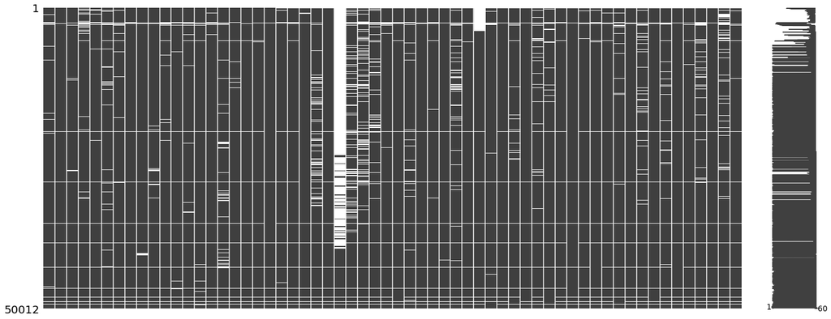

```python
#NaN check and order by stock name
msno.matrix(df)
percentage_of_missing_value=df.isna().mean()*100
print(percentage_of_missing_value.sort_values(ascending=False))
```

```python
#since 75% of ISDMR time series data is missing as can be easily seen from msno matrix, it is extracted from dataframe
df=df.drop(columns=['ISDMR'])
```

```python
# extract highest mean
highest_mean = summary.loc['mean'].idxmax(),summary.loc['mean'].max()

# extract lowest mean
lowest_mean = summary.loc['mean'].idxmin(),summary.loc['mean'].min()

# extract highest std dev
highest_std_dev = summary.loc['std'].idxmax(), summary.loc['std'].max()

# extract lowest std dev
lowest_std_dev = summary.loc['std'].idxmin(), summary.loc['std'].min()

# extract highest max value
highest_max = summary.loc['max'].idxmax(), summary.loc['max'].max()

# extract lowest min value
lowest_min = summary.loc['min'].idxmin(), summary.loc['min'].min()

print(f"Highest mean: {highest_mean}")
print(f"Lowest mean: {lowest_mean}")
print(f"Highest standard deviation: {highest_std_dev}")
print(f"Lowest standard deviation: {lowest_std_dev}")
print(f"Highest max value: {highest_max}")
print(f"Lowest min value: {lowest_min}")
```

```
Highest mean: ('OTKAR', 81.41952847596609)
Lowest mean: ('ISYAT', 0.5373379469248124)
Highest standard deviation: ('TUPRS', 32.39811716240987)
Lowest standard deviation: ('TSKB', 0.1552759969936095)
Highest max value: ('OTKAR', 139.4288)
Lowest min value: ('AKSEN', 0.0)
```

```python
#there are outliers in data, they need to be removed.
#They can distort the relationships between variables and potentially lead to misleading results.
z_scores=df.apply(zscore)
outliers=(z_scores>3)
df=df[~outliers]
```

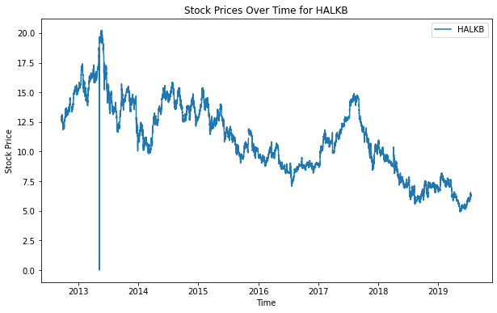

```python
#example plot for HALKB stock
plt.figure(figsize=(10, 6))
plt.plot(df.index, df['HALKB'], label='HALKB')

plt.xlabel('Time')
plt.ylabel('Stock Price')
plt.title('Stock Prices Over Time for HALKB')
plt.legend()
plt.show()
```

```python
#incorrect record
df=df.drop(df.loc[df.idxmin()].index)
```

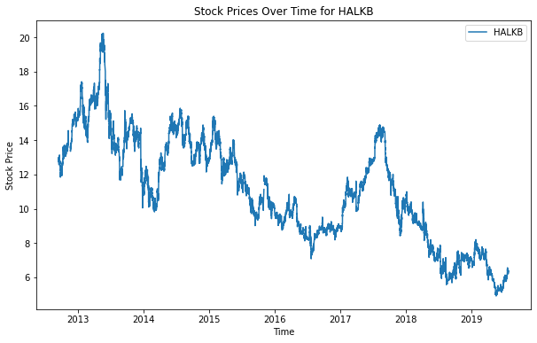

```python
#after dropping incorrect record
plt.figure(figsize=(10, 6))
plt.plot(df.index, df['HALKB'], label='HALKB')

plt.xlabel('Time')
plt.ylabel('Stock Price')
plt.title('Stock Prices Over Time for HALKB')
plt.legend()
plt.show()
```

```python
#since our data contains price info of stocks, it can not have any negative value
negative_prices=(df<0).any().any()

if negative_prices:
    print("There is negative prices in df ")
else:
    print("There isn't any negative price in df")
```

```
There isn't any negative price in df
```

Central tendency measure are mode, meadian and mean. They are important to understand the distribution of data in a dataset, providing insights into the typical or central value around which the data is centered.

```python
#measures of central tendency: median,mode,mean
mean_values = df.mean()
median_values = df.median()
mode_values=df.mode()

summary_ct = pd.DataFrame({'Mean': mean_values, 'Median': median_values, 'Mode': mode_values.iloc[0]})
summary_ct
```

|  | Mean | Median | Mode |
| --- | --- | --- | --- |
| AEFES | 20.982762 | 20.6465 | 21.1053 |
| AKBNK | 6.473273 | 6.3057 | 6.0781 |
| AKSA | 7.127724 | 6.9853 | 7.5387 |
| AKSEN | 3.183631 | 2.9300 | 2.8200 |
| ALARK | 2.060911 | 1.9376 | 1.3806 |
| ALBRK | 1.365561 | 1.3602 | 1.4953 |
| ANACM | 1.672159 | 1.2597 | 1.0684 |
| ARCLK | 15.388487 | 15.0150 | 11.1787 |
| ASELS | 13.433063 | 9.2757 | 7.2549 |
| ASUZU | 6.467274 | 5.9496 | 6.1998 |
| AYGAZ | 8.102191 | 7.7238 | 6.7894 |
| BAGFS | 10.407423 | 10.6100 | 11.8465 |
| BANVT | 7.628560 | 3.7100 | 2.3400 |
| BRISA | 6.545085 | 6.7300 | 7.0900 |
| CCOLA | 36.891479 | 34.8215 | 48.5013 |
| CEMAS | 1.209123 | 0.8700 | 0.7000 |
| ECILC | 2.075925 | 1.8214 | 1.1368 |
| EREGL | 4.179709 | 3.0360 | 0.7566 |
| FROTO | 32.764844 | 27.1182 | 20.8863 |
| GARAN | 7.899957 | 7.6542 | 7.0876 |
| GOODY | 3.102579 | 3.1929 | 3.2991 |
| GUBRF | 4.328444 | 4.2500 | 4.8800 |
| HALKB | 10.919609 | 10.6545 | 13.7700 |
| ICBCT | 2.828628 | 2.0300 | 1.9400 |
| ISCTR | 5.126693 | 4.8543 | 4.4666 |
| ISFIN | 1.559497 | 0.8635 | 0.5696 |
| ISYAT | 0.537354 | 0.4957 | 0.4683 |
| KAREL | 3.178162 | 1.8200 | 1.4000 |
| KARSN | 1.326951 | 1.2874 | 1.0908 |
| KCHOL | 12.248658 | 12.0449 | 9.4213 |
| KRDMB | 2.222853 | 2.2007 | 1.4577 |
| KRDMD | 1.768462 | 1.3979 | 1.0656 |
| MGROS | 19.576935 | 19.1100 | 19.1000 |
| OTKAR | 81.421398 | 82.8224 | 56.5573 |
| PARSN | 8.277316 | 7.8900 | 2.7000 |
| PETKM | 2.539326 | 2.2845 | 1.1612 |
| PGSUS | 24.790258 | 25.6400 | 28.5000 |
| PRKME | 2.927188 | 2.7400 | 2.0900 |
| SAHOL | 8.616103 | 8.6079 | 9.0519 |
| SASA | 2.295000 | 0.7335 | 0.2931 |
| SISE | 3.048466 | 2.6682 | 1.6302 |
| SKBNK | 1.473689 | 1.5100 | 1.1900 |
| SODA | 3.189711 | 2.6684 | 4.1716 |
| TCELL | 9.828284 | 9.7001 | 9.2560 |
| THYAO | 9.289151 | 7.7800 | 7.1600 |
| TKFEN | 9.192188 | 5.7532 | 3.8998 |
| TOASO | 16.597771 | 16.5554 | 9.9816 |
| TRKCM | 2.027916 | 1.6270 | 1.1694 |
| TSKB | 0.945260 | 0.9373 | 0.7600 |
| TTKOM | 5.660803 | 5.7464 | 6.2300 |
| TUKAS | 1.737563 | 1.5300 | 0.9700 |
| TUPRS | 62.996872 | 49.5542 | 34.3798 |
| USAK | 1.220495 | 1.0500 | 1.0058 |
| VAKBN | 4.735569 | 4.4759 | 4.2770 |
| VESTL | 5.942919 | 6.3200 | 1.9000 |
| YATAS | 2.434377 | 0.9658 | 0.2657 |
| YKBNK | 2.566391 | 2.6093 | 2.8740 |
| YUNSA | 4.079829 | 4.1078 | 2.3268 |
| ZOREN | 1.248159 | 1.2500 | 1.1700 |

Each stock exhibits different distribution patterns as can bee sen from histogram plot, which means that the frequency and range of stock price movements vary from one stock to another. To illustate, histogram of AEFES and histogram of VESTL can be compared.

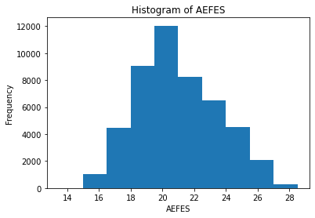

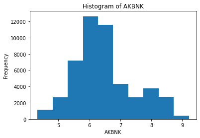

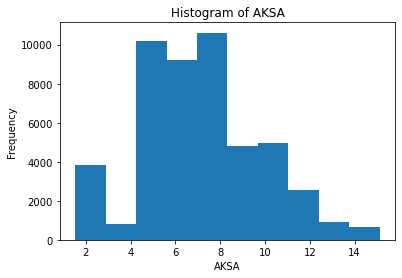

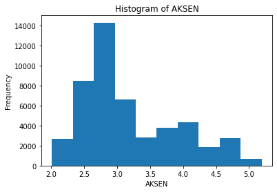

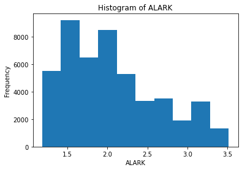

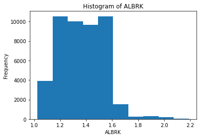

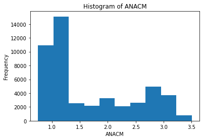

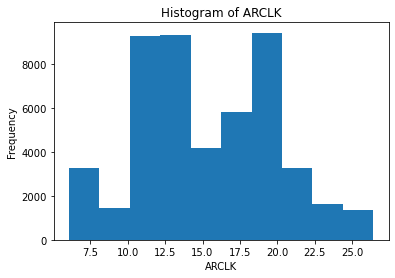

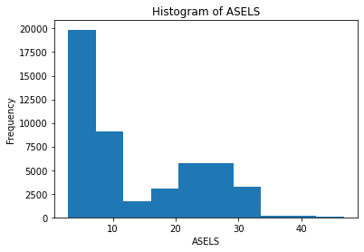

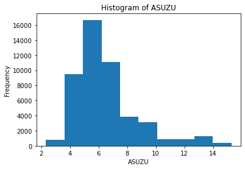

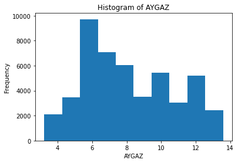

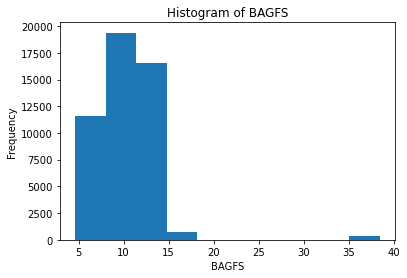

[47 more figures not shown]

```python
#histogram of df

for col in df.columns:
    plt.hist(df[col], bins=10)
    plt.title(f'Histogram of {col}')
    plt.xlabel(col)
    plt.ylabel('Frequency')
    plt.show()
```

Measure dispersion metrics are range, standard deviation, perentiles etc. as showm in summary df part in the preivous sctions and skewness and kurtosis.